# Coursework Report

*N* removed NAs: 3

*N* removed <18: 25

*N* total clean: 119

| Group | *N* | *M*<sub>age</sub> | *M*<sub>rating</sub> |
| --- | --- | --- | --- |
| Control | 58 | 21.07 | 6.05 |
| Experim | 61 | 20.39 | 5.37 |

**Main analysis results**

*t*(117) = 4.57, *p* < .001

# Coursework Report

Analysing Data, Spring 2020

# Methods

## Participants

Table 1 *Participants in Experiment 1*

| Condition | Total | Age Mean | Minimum Age | Maximum Age |
| --- | --- | --- | --- | --- |
| Control | 58 | 21.07 | 18 | 25 |
| Experimental | 61 | 20.39 | 18 | 25 |

## Design

Consistent with previous studies concerning red-attractiveness, for instance **Pazda, Elliot and Greitemeyer (2013)** where men rated women who wore red clothing as being more attractive, as well as **Thorstenson et al. (2017)** who found that women rated men with facial-redness as more appealing, the main hypothesis of this study was that the colour red would have significant positive effects on how women perceive men.

As an attempt to replicate **Elliot et al.’s (2010)** study on the effects of red on attractiveness among women toward men, this study adopted a similar procedure. The current experiment was a between-subject design, in which there were 2 main conditions: participants in control and experimental conditions would respectively view a photo of a man surrounded by white and red background. The participants would then be asked to rate the photo based on 3 measuring items, which were simple statements in the order of, “How attractive do you think this person is?”, “How pleasant is this person to look at?” and lastly “If I were to meet the person in this picture face to face, I would think he is attractive.”. The items were answered accordingly to a 9-point Likert scale, in which 1 was indicative of *not at all attractive* and 9 was *extremely attractive*. Both the items and photo were the main subjects of manipulation in this study.

The ratings of these items was ultimately averaged into one composite score for each participant, referred to as the “attractive mean”, this was also the primary dependent variable of this study. Hence, the operational hypothesis of the current experiment was that the overall attractive mean produced by participants in the ‘red’ (experimental condition) would be higher than that resulted in the control group, i.e ‘white’ condition. In order to test this hypothesis, an independent *t*-test was conducted on purpose of comparing the means of two groups of participants.

# Results

Table 2 *Mean attractiveness of each condition*

| Conditions | Attractive mean |
| --- | --- |
| Control | 6.05 |
| Experimental | 5.37 |

As demonstrated in *Table 2*, there was a difference in the findings between two participants groups, despite the fact that both means were not considered remarkably high on a scale of 1-9. Particularly, the measure for attractiveness in the study, “attractive mean” was greater in the control condition comparing to that of the experimental condition. To examine the significance of this difference, an independent *t*-test was conducted. The results revealed that the difference between the two means was significant (*M*<sub>diff</sub> = 0.67, 95% CI [0.38, 0.97]). Additionally, there was also a signficant difference in ratings of attractiveness between the two conditions (*t* (117) = 4.57, *p* = .00001).

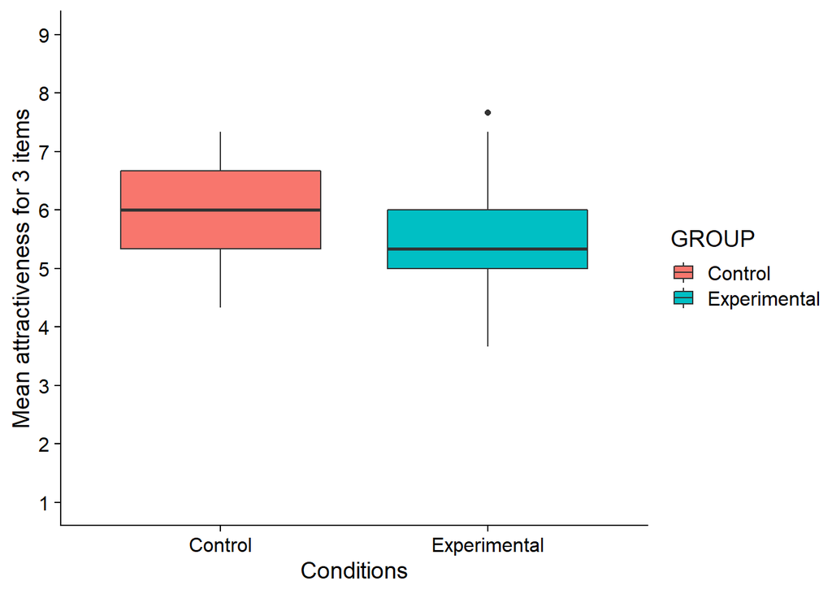

# Discussion

In general, the main hypothesis was not supported by the findings of this experiment. Specifically, the initial prediction was that the measure of attractiveness (“attractive mean”) would be greater in the ‘red’ (experimental) condition than that comparing to the ‘white’ (control) condition. However, the results demonstrated an opposing pattern, where the participants in the control group displayed significantly more attractiveness to the subject than those in the experimental group. Thus, the findings in this study was not consistent with what was reported in **Elliot et al.’s (2010)** original study.

The current study posseses some limitations, most of them can be recognised in the experimental design. Firstly, the participants were presented a single stimulus as a target for rating attractiveness. The lack of consideration over personal partner preferences, for example skin tone and/or hair colour, thus, might not reflect how attractiveness is elicited in normal, everyday life setting. Relatively, another limitation of this study comes from the fact that it has failed to control racial variation in the targets shown. Despite the fact it was proposed that one’s attractiveness ratings would be similar across cultures **(Zhou, Short, Chan, Mondloch, 2016)**, this lack of variation might nonetheless affect the generalisablity of this study. However, it is essential to note that the **Elliot et al.’s (2010)** original study also suffered from similar limitations, where the original design might be too simple to conclude that red colour has any effects on attractiveness. Hence, it is reasonable to put into question the robustness of the red-effect.

With ongoing debates over whether or not red-attractiveness was legitimate, the current study calls for more investigation into the nature of this effect, in order to reach a reliable conclusion. A way to do this which future research can consider is by testing the universality of the red-attractiveness effect. If this effect is indeed remarkable, then it must be replicable into global context to a certain extent. This can be done by replicating the study in different cultures, and/or controlling the racial variation in the stimuli provided. Additionally, in order to improve the probability of chance that the original study was critised of, as well as to examine the effects of red colour in a macro setting, future studies should be conducted with a reliably larger sample. Furthermore, large samples are extremely essential as they also contribute greatly to producing reliable findings.

To conclude, this experiment has attempted to replicate **Elliot et al.’s (2010)** study concerning the effects of the colour red on how women perceive men. The main hypothesis was not supported by any of the findings, in which the attractive ratings for the control group was significantly higher comparing to the experimental group. Before submitting to any decisive conclusion about the legitimacy of this effect, it is crucial that more replications need to be conducted to examine its’ robustness.

# References

Elliot, A. J., Niesta Kayser, D., Greitemeyer, T., Lichtenfeld, S., Gramzow, R. H. (2010). Red, Rank, and Romance in Women Viewing Men. Journal of Experimental Psychology: General, 139(3), 399-417. DOI: 10.1037/a0019689

Pazda, A. D., Elliot, A. J., Greitemeyer, T. (2013). Perceived Sexual Receptivity and Fashionableness: Separate Paths Linking Red and Black to Perceived Attractiveness. Color Research and Application, 39(2), 208-212.

Peperkoorn, L. S., Roberts, S. C., Pollet, T. V. (2016). Revisiting the Red Effect on Attractiveness and Sexual Receptivity: No Effect of the Color Red on Human Mate Preferences. Evolutionary Psychology, 1-13. DOI: 10.1177/1474704916673841

Pollet, T. V., Costello, J., Groeneboom, L., Peperkoorn, L. S., Wu, J. (2019). Do Red Objects Enhance Sexual Attractiveness? No Evidence from Two Large Replications. Displays, 56, 23-29.

Thorstenson, C. A., Pazda, A. D., Elliot, A. J., Perrett, D. I. (2017). Facial Redness Increases Men’s Perceived Healthiness and Attractiveness. Perception, 46(6), 650-664. DOI: 10.1177/0301006616680124

Zhou, X., Short, L. A., Chan, H. S. J., Mondloch, C. J. (2016). Judging Normality and Attractiveness in Faces: Direct Evidence of a More Refined Representation for Own-Race, Young Adult Faces. Perception, 45(9), 973-990. DOI: 10.1177/0301006616652044